# Data Mining Week 1

Aaron Wright

07/03/2021

## The WeatherPlay dataset

Let’s view the `WeatherPlay` data set. This is part of the `partykit` library.

```r
view(WeatherPlay)
head(WeatherPlay)
```

```
##    outlook temperature humidity windy play
## 1    sunny          85       85 false   no
## 2    sunny          80       90  true   no
## 3 overcast          83       86 false  yes
## 4    rainy          70       96 false  yes
## 5    rainy          68       80 false  yes
## 6    rainy          65       70  true   no
```

Checking the dimensions and attributes of the data

```r
glimpse(WeatherPlay)
```

```
## Rows: 14
## Columns: 5
## $ outlook     <fct> sunny, sunny, overcast, rainy, rainy, rainy, overcast, sun…
## $ temperature <dbl> 85, 80, 83, 70, 68, 65, 64, 72, 69, 75, 75, 72, 81, 71
## $ humidity    <dbl> 85, 90, 86, 96, 80, 70, 65, 95, 70, 80, 70, 90, 75, 91
## $ windy       <fct> false, true, false, false, false, true, true, false, false…
## $ play        <fct> no, no, yes, yes, yes, no, yes, no, yes, yes, yes, yes, ye…
```

Let’s just return the names of the columns and dimensions, and save to variables

```r
columns <- names(WeatherPlay)
col_total <- ncol(WeatherPlay)
row_total <- nrow(WeatherPlay)

columns
```

```
## [1] "outlook"     "temperature" "humidity"    "windy"       "play"
```

```r
col_total
```

```
## [1] 5
```

```r
row_total
```

```
## [1] 14
```

Summary of data

```r
summary(WeatherPlay)
```

```
##      outlook   temperature       humidity       windy    play
##  sunny   :5   Min.   :64.00   Min.   :65.00   false:8   yes:9
##  overcast:4   1st Qu.:69.25   1st Qu.:71.25   true :6   no :5
##  rainy   :5   Median :72.00   Median :82.50
##               Mean   :73.57   Mean   :81.64
##               3rd Qu.:78.75   3rd Qu.:90.00
##               Max.   :85.00   Max.   :96.00
```

### Applying J48 Classification Tree to the WeatherData data set

`train` is a method from the `caret` library that we can use to fit a model to the training data.

`play ~.` instructs the model to predict play column (target variable) using all other columns (feature variables).

`data` parameter tells us which data frame to use.

`method` tells it which tree building algorithm to use.

`trControl` is optional. This provides instructions on how to train the model. In the below case, we are saying to do a Cross-Validation repeated 5 times.

```r
# Set random number seed so that we get the same result each time we run the script
set.seed(1)

# How we want to train the model
control <- trainControl(method = "cv", number = 5)

# Let's fit a model to the training data, using the J48 tree building algorithm
j48Tree <- train(play  ~., data = WeatherPlay, method = "J48", trControl = control)

# Let's print a summary of our final model
summary(j48Tree$finalModel)
```

```
##
## === Summary ===
##
## Correctly Classified Instances          13               92.8571 %
## Incorrectly Classified Instances         1                7.1429 %
## Kappa statistic                          0.8511
## Mean absolute error                      0.1071
## Root mean squared error                  0.2315
## Relative absolute error                 23.0769 %
## Root relative squared error             48.2711 %
## Total Number of Instances               14
##
## === Confusion Matrix ===
##
##  a b   <-- classified as
##  8 1 | a = yes
##  0 5 | b = no
```

In the data set, there are 9 `yes` and 5 `no`. However, the confusion matrix above tells us that our model predicted 8 `yes` and 6 `no`.

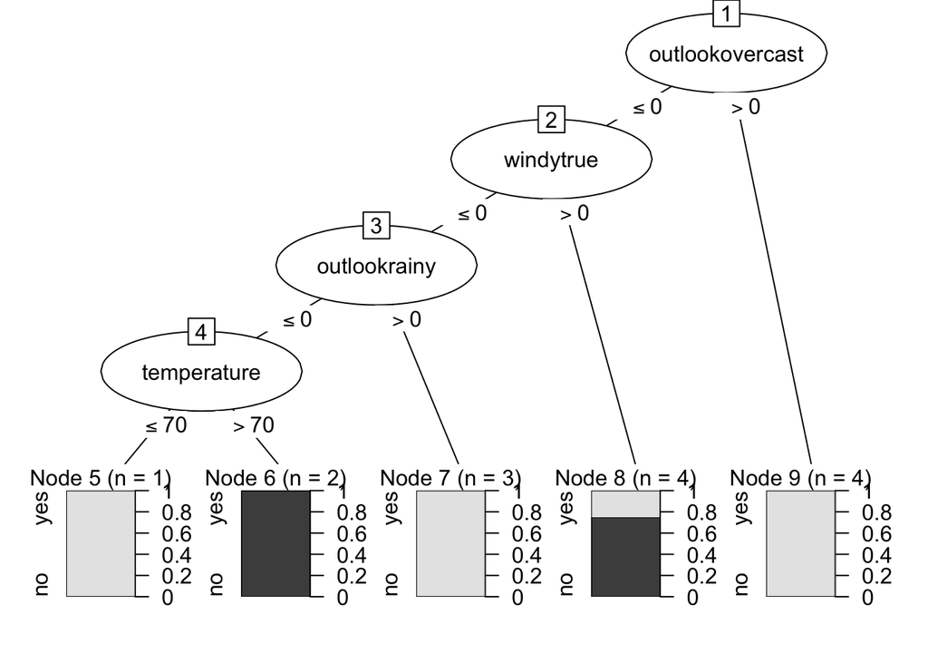

```r
plot(j48Tree$finalModel)
```

### Apply C5.0 Tree Model to WeatherData

C5.0 is another algorithm for classification trees.

```r
set.seed(1)
control <- trainControl(method = "cv", number = 5)
c5Tree <- train(play ~., data = WeatherPlay, method = "C5.0Tree", trControl = control)

summary(c5Tree$finalModel)
```

```
##
## Call:
## C50:::C5.0.default(x = x, y = y, weights = wts)
##
##
## C5.0 [Release 2.07 GPL Edition]      Sun Mar  7 15:31:04 2021
## -------------------------------
##
## Class specified by attribute `outcome'
##
## Read 14 cases (6 attributes) from undefined.data
##
## Decision tree:
##
## outlookovercast > 0: yes (4)
## outlookovercast <= 0:
## :...windytrue <= 0: yes (6/2)
##     windytrue > 0: no (4/1)
##
##
## Evaluation on training data (14 cases):
##
##      Decision Tree
##    ----------------
##    Size      Errors
##
##       3    3(21.4%)   <<
##
##
##     (a)   (b)    <-classified as
##    ----  ----
##       8     1    (a): class yes
##       2     3    (b): class no
##
##
##  Attribute usage:
##
##  100.00% outlookovercast
##   71.43% windytrue
##
##
## Time: 0.0 secs
```

We can see our results are slightly different using this algorithm.

**Random Note**

When deciding what feature variable should be at the top of the tree (aka the Root) we look at something called **Purity**.

So for example, if we were only looking `windy` and `play` in our training data, we would place `windy` as the Root. We would then create two branches: **True** and **False**. Then, we would create a **node** for each of these. Then going through each record in our data set, if `windy` was **True** and `play` was **True** we would then look at the node branching off of **True** and add 1 next to **True** (for `play`). We would do this for all records. If neight of the leaf nodes are 100% **True Play** or 100% **False Play** - then they are both considered **Impure**.

For this data set, this is done for all variables, not just `windy`. We may find none of them are **pure**. Thus, we need a way to measure and compare **impurity** so we know which order to place the decision nodes.

We would calculate `Gini` impurity for each leaf:

Gini Impurity = `1 - (probability of True)squared - (probability of False)squared`

We would do this for both leaf nodes for `windy` as an example.

We would then take the weighted average of these two results to give the total. We would then do this for the other feature variables.

Once all this is done, we would look for the feature variable that has the **lowest** Gini impurity and use that as the root of the tree (in this case, it may be `windy`)

We would then look at each node coming off of the root `windy` node, and see how well the other variables do at further breaking this down. So for the `windy True` node, we may have 10 **True** and 2 **False** (as an example). We would then follow the same Gini Impurity process above for these values, and identify the variable with the lowest impurity.

Something becomes a leaf node it if has the lowest Gini Impurity Score.

If we’re dealing with numerical data, the process would be slightly different. We would sort the data. Then calculate the average of each adjacent value. So for example, our first two values in the column may be 155 and 180. The average here would be 167.5. We would therefore put 165 has the root, with one branch being under 167.5, the other being above. We can then calculate the impurity score. We would do this for ever single average that we’ve calculated, following the same procedure as above. If we found that > or < 167.5 had the lowest Gini value, we would use this as the cutoff value when comparing against other variables.

Ranked data is similar to numeric data. We calculate impurity scores for all ranks (e.g. less than or equal to 1, or less than or equal to 2, etc).

For colors, we calculate an impurity score for each color, as well as each combination of colors.

There’s more to it than this, but we’ll leave it there for now.

### Using an Association

One alternative to a decision tree model is a decision tree rules model. One such model is the `C5.0Rules` algorithm

```r
set.seed(1)
control <- trainControl(method = "cv", number = 5)
c5Rules <- train(play ~., data = WeatherPlay, method = "C5.0Rules", trControl = control)

summary(c5Rules$finalModel)
```

```
##
## Call:
## C50:::C5.0.default(x = x, y = y, rules = TRUE, weights = wts)
##
##
## C5.0 [Release 2.07 GPL Edition]      Sun Mar  7 15:31:06 2021
## -------------------------------
##
## Class specified by attribute `outcome'
##
## Read 14 cases (6 attributes) from undefined.data
##
## Rules:
##
## Rule 1: (4, lift 1.3)
##  outlookovercast > 0
##  ->  class yes  [0.833]
##
## Rule 2: (8/2, lift 1.1)
##  windytrue <= 0
##  ->  class yes  [0.700]
##
## Rule 3: (4/1, lift 1.9)
##  outlookovercast <= 0
##  windytrue > 0
##  ->  class no  [0.667]
##
## Default class: yes
##
##
## Evaluation on training data (14 cases):
##
##          Rules
##    ----------------
##      No      Errors
##
##       3    3(21.4%)   <<
##
##
##     (a)   (b)    <-classified as
##    ----  ----
##       8     1    (a): class yes
##       2     3    (b): class no
##
##
##  Attribute usage:
##
##   85.71% windytrue
##   57.14% outlookovercast
##
##
## Time: 0.0 secs
```

### using the Segmentation Data data set.

Load the data set and examine it.

```r
data(segmentationData)
view(segmentationData)
glimpse(segmentationData)
```

```
## Rows: 2,019
## Columns: 61
## $ Cell                    <int> 207827637, 207932307, 207932463, 207932470, 20…
## $ Case                    <fct> Test, Train, Train, Train, Test, Test, Test, T…
## $ Class                   <fct> PS, PS, WS, PS, PS, WS, WS, PS, WS, WS, WS, WS…
## $ AngleCh1                <dbl> 143.247705, 133.752037, 106.646387, 69.150325,…
## $ AreaCh1                 <int> 185, 819, 431, 298, 285, 172, 177, 251, 495, 3…
## $ AvgIntenCh1             <dbl> 15.71186, 31.92327, 28.03883, 19.45614, 24.275…
## $ AvgIntenCh2             <dbl> 4.954802, 206.878517, 116.315534, 102.294737, …
## $ AvgIntenCh3             <dbl> 9.548023, 69.916880, 63.941748, 28.217544, 20.…
## $ AvgIntenCh4             <dbl> 2.214689, 164.153453, 106.696602, 31.028070, 4…
## $ ConvexHullAreaRatioCh1  <dbl> 1.124509, 1.263158, 1.053310, 1.202625, 1.1093…
## $ ConvexHullPerimRatioCh1 <dbl> 0.9196827, 0.7970801, 0.9354750, 0.8658291, 0.…
## $ DiffIntenDensityCh1     <dbl> 29.51923, 31.87500, 32.48771, 26.73228, 31.580…
## $ DiffIntenDensityCh3     <dbl> 13.77564, 43.12228, 35.98577, 22.91732, 21.709…
```

[output cut: 48 more lines]

```r
head(segmentationData)
```

```
##        Cell  Case Class   AngleCh1 AreaCh1 AvgIntenCh1 AvgIntenCh2 AvgIntenCh3
## 1 207827637  Test    PS 143.247705     185    15.71186    4.954802    9.548023
## 2 207932307 Train    PS 133.752037     819    31.92327  206.878517   69.916880
## 3 207932463 Train    WS 106.646387     431    28.03883  116.315534   63.941748
## 4 207932470 Train    PS  69.150325     298    19.45614  102.294737   28.217544
## 5 207932455  Test    PS   2.887837     285    24.27574  112.415441   20.474265
## 6 207827656  Test    WS  40.748298     172   325.93333  653.606061  128.690909
##   AvgIntenCh4 ConvexHullAreaRatioCh1 ConvexHullPerimRatioCh1
## 1    2.214689               1.124509               0.9196827
## 2  164.153453               1.263158               0.7970801
## 3  106.696602               1.053310               0.9354750
## 4   31.028070               1.202625               0.8658291
## 5   40.577206               1.109333               0.9568124
## 6  346.854545               1.005831               0.9926363
##   DiffIntenDensityCh1 DiffIntenDensityCh3 DiffIntenDensityCh4 EntropyIntenCh1
```

[output cut: 76 more lines]

Let’s remove the `Cell` Column, as it’s just a unique ID and doesn’t really give us anything.

```r
segmentationData$Cell <- NULL
head(segmentationData)
```

```
##    Case Class   AngleCh1 AreaCh1 AvgIntenCh1 AvgIntenCh2 AvgIntenCh3
## 1  Test    PS 143.247705     185    15.71186    4.954802    9.548023
## 2 Train    PS 133.752037     819    31.92327  206.878517   69.916880
## 3 Train    WS 106.646387     431    28.03883  116.315534   63.941748
## 4 Train    PS  69.150325     298    19.45614  102.294737   28.217544
## 5  Test    PS   2.887837     285    24.27574  112.415441   20.474265
## 6  Test    WS  40.748298     172   325.93333  653.606061  128.690909
##   AvgIntenCh4 ConvexHullAreaRatioCh1 ConvexHullPerimRatioCh1
## 1    2.214689               1.124509               0.9196827
## 2  164.153453               1.263158               0.7970801
## 3  106.696602               1.053310               0.9354750
## 4   31.028070               1.202625               0.8658291
## 5   40.577206               1.109333               0.9568124
## 6  346.854545               1.005831               0.9926363
##   DiffIntenDensityCh1 DiffIntenDensityCh3 DiffIntenDensityCh4 EntropyIntenCh1
```

[output cut: 76 more lines]

This dataset actually has a column, as you can see, which specified which record should be considered training data, and which should be considered test data. Let’s split the data into two separate data frames based on this.

```r
STrain <- segmentationData %>% filter(Case == "Train")
STest <- segmentationData %>% filter(Case == "Test")
```

We can now remove the `Case` column.

```r
STrain$Case <- NULL
STest$Case <- NULL
```

Let’s now build a J48 model from this data.

```r
set.seed(1)
control <- trainControl(method = 'cv', number = 5)
STree <- train(Class ~., data = STrain, method = 'J48', trControl = control)

summary(STree$finalModel)
```

```
##
## === Summary ===
##
## Correctly Classified Instances         909               90.0892 %
## Incorrectly Classified Instances       100                9.9108 %
## Kappa statistic                          0.784
## Mean absolute error                      0.1666
## Root mean squared error                  0.2886
## Relative absolute error                 35.736  %
## Root relative squared error             59.7839 %
## Total Number of Instances             1009
##
## === Confusion Matrix ===
##
##    a   b   <-- classified as
##  600  36 |   a = PS
##   64 309 |   b = WS
```

Results seem pretty good. The model correctly classifies instances 90% of the time.

```r
summary(STree$results)
```

```
##        C               M        Accuracy          Kappa
##  Min.   :0.010   Min.   :1   Min.   :0.7661   Min.   :0.4964
##  1st Qu.:0.010   1st Qu.:1   1st Qu.:0.7691   1st Qu.:0.5021
##  Median :0.255   Median :2   Median :0.7731   Median :0.5138
##  Mean   :0.255   Mean   :2   Mean   :0.7824   Mean   :0.5333
##  3rd Qu.:0.500   3rd Qu.:3   3rd Qu.:0.8047   3rd Qu.:0.5824
##  Max.   :0.500   Max.   :3   Max.   :0.8067   Max.   :0.5898
##    AccuracySD         KappaSD
##  Min.   :0.03261   Min.   :0.06595
##  1st Qu.:0.03362   1st Qu.:0.07115
##  Median :0.03598   Median :0.07856
##  Mean   :0.03597   Mean   :0.07680
##  3rd Qu.:0.03746   3rd Qu.:0.08119
##  Max.   :0.03893   Max.   :0.08681
```

[figure not shown]

```r
plot(STree$finalModel)
```

It’s normal for our model to perform well on our training dataset. However, on unseen data, the model is likely to perform worse. This is why we created a separate testing dataset.

1. Use the model to predict the target variable for the test set.
2. Compare this with the actual target variable values.